# Web Scraping and Analysis of Football Players’ Statistics

# 1 Introduction

## 1.1 Project Background

Fantasy football has evolved from a niche hobby into a global phenomenon, with millions of participants worldwide making weekly decisions about their virtual teams. The success in fantasy football heavily relies on the ability to accurately predict player performance based on historical data and current trends. This project aims to bridge the gap between raw statistical data and actionable insights through web scraping and advanced analytics.

## 1.2 Project Objectives

The main objectives of this project are:

1. **Data Collection**: Systematically gather comprehensive player statistics from reliable football statistics websites using web scraping techniques in R. Due to the dynamically loaded nature of the target website, parsing data directly from the HTML was not possible. Instead, the data was extracted from JSON files loaded by the website, which required additional steps to identify and process the relevant API endpoints.
2. **Performance Analysis**: Analyze historical performance data to identify patterns and trends to find some unexpected insights in the data.
3. **Insight Generation**: Develop actionable recommendations for fantasy football managers based on the discovered patterns and statistical analysis.

## 1.3 Significance

This project holds significance for several reasons:

1. **Practical Application**: The findings can be directly applied to fantasy football strategy, helping both casual players and experienced managers make more informed decisions about team selection and transfers in the English Premier League Fantasy game.
2. **Data Science Skills Development**: The project demonstrates the practical application of various data science skills, including:
- Web scraping
- Data cleaning and preprocessing
- JSON file parsing
- Statistical analysis
- Predictive modeling
- Data visualization
3. **Sports Analytics Innovation**: Contributing to the growing field of sports analytics by combining traditional statistics with modern data science techniques.

## 1.4 Scope and Limitations

While the project aims to provide valuable insights for fantasy football managers, it’s important to acknowledge its scope and limitations. Additionally, the reliance on JSON files for data extraction introduced some complexity, as the structure of the files required careful inspection and processing to ensure accurate data collection.

# 2 Data Collection Process

## 2.1 Architecture

The project is organized into three main files, each with a specific role in the data collection and processing pipeline:

```
project/
├── data_visualization/     # Files used in data visualization
└── data_collection/
    ├── main.R              # Main execution script
    ├── utils.R             # Utility functions for HTTP requests and data handling
    └── stats_processor.R   # Data processing and transformation functions
```

## 2.2 File Responsibilities:

- `main.R`: The central script that orchestrates the entire process, including data fetching, processing, and saving.
- `utils.R`: Contains utility functions for HTTP requests, JSON parsing, and basic data operations.
- `stats_processor.R`: Implements the core logic for processing and transforming raw statistics data into structured formats.

## 2.3 File Relationships:

The following diagram illustrates the relationships between the files:

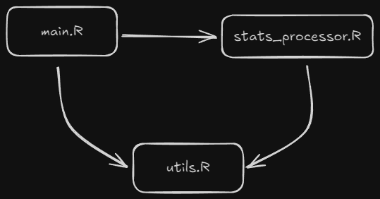

File relationships diagram

## 2.4 Libraries Used

The following R libraries were used to implement the data collection process:

```r
library(tidyverse)  # Collection of data manipulation packages
library(httr)       # HTTP request handling
library(jsonlite)   # JSON parsing and manipulation
```

```r
library(stringi)    # String manipulation

# Used for plotting
library(tidyverse)
library(ggplot2)
library(fmsb)
```

These libraries were chosen for their efficiency and ease of use in handling web scraping, JSON parsing, and data manipulation tasks.

## 2.5 Key Functions

### 2.5.1 Utils.R Functions

The `utils.R` file contains utility functions that handle HTTP requests, JSON parsing, and other basic operations. Below are some of the key functions:

```r
#' Create basic headers for HTTP requests
create_basic_headers()
# Purpose: Creates standardized headers for API requests
# Returns: List of HTTP headers

#' Fetch data from URL with retry logic
fetch_data(url, retry_count = 3, delay = 2)
# Purpose: Makes HTTP GET requests with retry mechanism
# Parameters:
#   - url: API endpoint URL
#   - retry_count: Number of retry attempts
#   - delay: Delay between retries in seconds
# Returns: HTTP response or NULL

#' Parse JSON response
parse_json_response(response)
# Purpose: Converts HTTP response to JSON object
# Parameters:
#   - response: HTTP response object
# Returns: Parsed JSON data
```

### 2.5.2 Stats Processor Functions

The `stats_processor.R` file contains functions for processing and transforming raw statistics data. Key functions include:

```r
#' Process single statistic data
process_stat_data(stat_data, stat_title)
# Purpose: Transforms raw stat data into structured format
# Parameters:
#   - stat_data: Raw JSON data for a statistic
#   - stat_title: Name of the statistic
# Returns: Processed data frame

#' Merge multiple statistics
merge_stats(existing_df, new_df, stat_title)
# Purpose: Combines multiple statistics while handling duplicates
# Parameters:
#   - existing_df: Current combined data frame
#   - new_df: New statistics to merge
#   - stat_title: Name of the statistic
# Returns: Merged data frame
```

## 2.6 Data Transformation Process

The data collection and transformation process consists of the following steps:

### 2.6.1 Step 1: Initial Data Fetch

The main JSON file containing links to individual statistics is fetched using the fetch_data() function:

```r
# Fetch main JSON containing links to individual statistics
main_json <- fetch_data(api_url) %>% parse_json_response()
```

### 2.6.2 Step 2: Extract Statistics Links

The JSON response is parsed to extract URLs and titles for individual statistics:

```r
# Extract URLs and titles for individual statistics
stats <- main_json$pageProps$stats$players
stat_urls <- stats$fetchAllUrl
stat_titles <- stats$header
```

### 2.6.3 Step 3: Process Individual Statistics

Each statistic is processed using the following steps:

1. Fetch JSON data using an HTTP GET request.
2. Parse the JSON response.
3. Extract relevant fields.
4. Convert the data into a structured data frame.
5. Standardize column names.
6. Convert data types for consistency.

### 2.6.4 Step 4: Data Cleaning

The processed data is cleaned to ensure consistency and accuracy:

1. Handle missing values.
2. Convert string values to numeric where applicable.
3. Standardize player IDs.
4. Remove duplicate information.

## 2.7 Joining/Merging Strategy

To combine multiple statistics into a single dataset, a robust merging strategy was implemented:

### 2.7.1 Key Concepts

1. Full Join: Preserves all records from both data frames.
2. Key Fields: Uses player ID and name as joining keys.
3. Conflict Resolution: Handles duplicate columns and conflicting values.

### 2.7.2 Merging Process

The merging process is implemented in the merge_stats() function:

```r
#' Merge multiple statistics with detailed explanation
merge_stats <- function(existing_df, new_df) {
  # Step 1: Prepare keys for joining
  joining_keys <- c("ParticipantId", "ParticipantName")

  # Step 2: Handle duplicate columns
  new_df <- new_df %>%
    select(-any_of(c("TeamName", "MinutesPlayed", "MatchesPlayed")))

  # Step 3: Perform full join
  merged_df <- existing_df %>%
    full_join(
      new_df,
      by = joining_keys,
      relationship = "one-to-one"
    ) %>%
    # Step 4: Handle conflicting columns
    mutate(
      MinutesPlayed = pmax(MinutesPlayed.x, MinutesPlayed.y, na.rm = TRUE),
      MatchesPlayed = pmax(MatchesPlayed.x, MatchesPlayed.y, na.rm = TRUE)
    ) %>%
    # Step 5: Clean up temporary columns
    select(-ends_with(".x"), -ends_with(".y"))

  return(merged_df)
}
```

### 2.7.3 Merging Rules

- Keep the highest value for minutes and matches played.
- Preserve player information across all statistics.
- Handle missing values consistently.
- Maintain data integrity during merging.

### 2.7.4 Output Example

Here is how my data looked like:

```r
data_player <- read_csv("E:/UNI_stuff/2-sem/Web Scraping/Project/Main/temp/data/player_stats_20250130_010255.csv")
glimpse(data_player)
```

```
## Rows: 561
## Columns: 73
## $ ParticipantName                            <chr> "Ashley Young", "Lukasz Fab…
## $ player_id                                  <dbl> 23354, 30973, 37234, 38807,…
## $ TeamName                                   <chr> NA, NA, NA, NA, NA, NA, NA,…
## $ MinutesPlayed                              <dbl> 0, 0, 0, 0, 0, 0, 0, 1086, …
## $ MatchesPlayed                              <dbl> 0, 0, 0, 0, 0, 0, 0, 14, 0,…
## $ Top_scorer                                 <dbl> 0, 0, 0, 0, 0, 0, 0, 1, 0, …
## $ Top_scorer_subtitle                        <dbl> 0, 0, 0, 0, 0, 0, 0, 0, 0, …
## $ Assists                                    <dbl> 0, 0, 1, 2, 1, 0, 0, 0, 0, …
## $ Assists_subtitle                           <dbl> 0.0, 0.0, 2.0, 1.7, 0.3, 0.…
## $ `Goals_+_Assists`                          <dbl> 0, 0, 1, 2, 1, 0, 0, 1, 0, …
## $ `Goals_+_Assists_subtitle`                 <dbl> 0.0, 0.0, 2.8, 2.0, 0.7, 0.…
## $ FotMob_rating                              <dbl> 6.67, 0.00, 6.29, 0.00, 6.8…
## $ FotMob_rating_subtitle                     <dbl> 0, 0, 0, 0, 0, 0, 0, 0, 1, …
```

[output cut: 60 more lines]

# 3 Data Analysis

## 3.1 Goals vs. Expected Goals (xG)

Expected Goals (xG) is a key metric in football analytics that estimates the likelihood of a shot resulting in a goal. Comparing actual goals scored with xG provides insights into a player’s finishing ability and whether they are overperforming or underperforming relative to expectations.

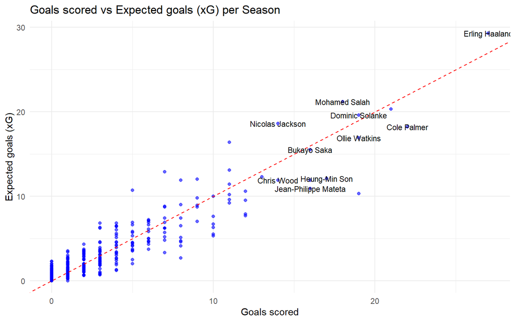

```r
# Code used for Goals vs xG plot
ggplot(data_player, aes(x = Top_scorer, y = `Expected_goals_(xG)`)) +
  geom_point(color = "blue", alpha = 0.6) +
  geom_abline(slope = 1, intercept = 0, linetype = "dashed", color = "red") +
  geom_text(
    data = data_player %>%
      filter(Top_scorer > 12 & `Expected_goals_(xG)` > 7),
    aes(label = ParticipantName),
    size = 3,
    check_overlap = T
  ) +
  labs(
    title = "Goals scored vs Expected goals (xG) per Season",
    x = "Goals scored",
    y = "Expected goals (xG)"
  ) +
  theme_minimal()
```

**Insights**:

- Players below the red dashed line are overperforming their xG, indicating exceptional finishing ability.
- Players above the line are underperforming their xG, suggesting inefficiency in converting chances.

## 3.2 Assists vs. Expected assists (xA)

Expected Assists (xA) measures the likelihood that a pass will result in a goal. Comparing actual assists with xA helps identify players who are creating high-quality chances and those who are benefiting from teammates’ finishing ability.

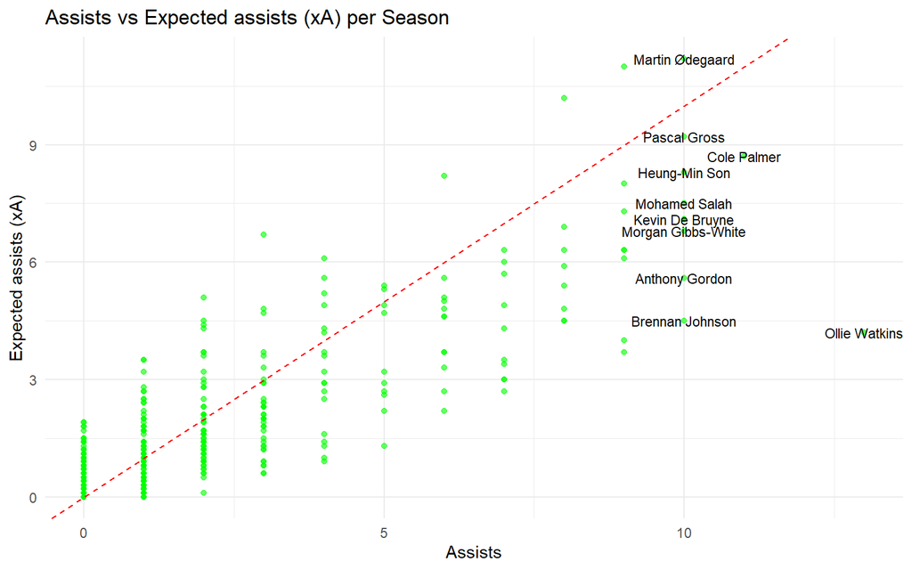

```r
# Assists vs xA
ggplot(data_player, aes(x = Assists, y = `Expected_assist_(xA)`)) +
  geom_point(color = "green", alpha = 0.6) +
  geom_abline(slope = 1, intercept = 0, linetype = "dashed", color = "red") +
  geom_text(
    data = data_player %>%
      filter(Assists > 9 & `Expected_assist_(xA)` > 4),
    aes(label = ParticipantName),
    size = 3,
    check_overlap = T
  ) +
  labs(
    title = "Assists vs Expected assists (xA) per Season",
    x = "Assists",
    y = "Expected assists (xA)"
  ) +
  theme_minimal()
```

**Insights**:

- Players below the red dashed line are overperforming their xA, indicating they are benefiting from teammates’ finishing ability.
- Players above the line are underperforming their xA, suggesting inefficiency in converting high-quality chances into assists.

## 3.3 Top 15 Players by Assists

Confirmation of data mentioned above.

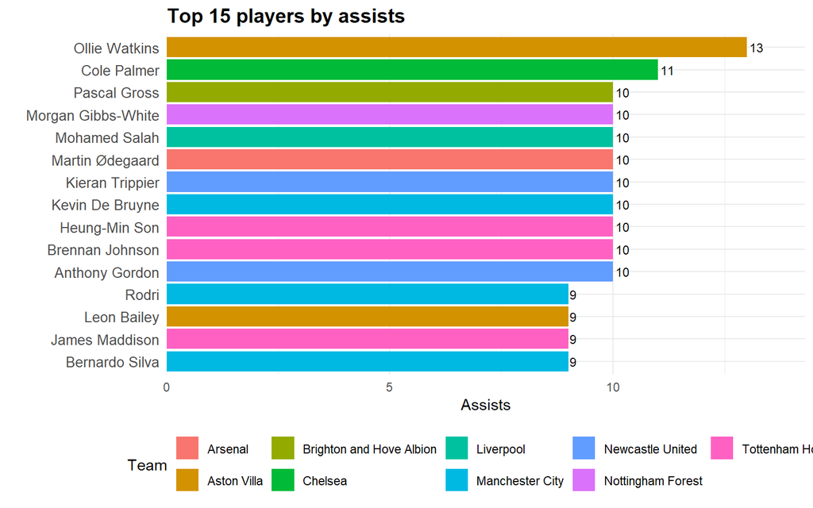

```r
ggplot(
  data_player %>%
    arrange(desc(Assists)) %>%
    head(15),  # Top 15 players
  aes(x = reorder(ParticipantName, Assists), y = Assists, fill = TeamName)
) +
  geom_bar(stat = "identity") +
  coord_flip() +
  geom_text(
    aes(label = sprintf("%d", Assists)),
    hjust = -0.2,
    size = 3
  ) +
  labs(
    title = "Top 15 players by assists",
    x = "",
    y = "Assists",
    fill = "Team"
  ) +
  theme_minimal() +
  theme(
    plot.title = element_text(size = 14, face = "bold"),
    plot.subtitle = element_text(size = 12),
    axis.text.y = element_text(size = 10),
    legend.position = "bottom",
    legend.box = "horizontal"
  ) +
  scale_y_continuous(expand = c(0, 0, 0.1, 0)) +  # Adjust y-axis limits
  guides(fill = guide_legend(nrow = 2))  # Arrange legend in two rows
```

## 3.4 Top 3 Players Comparison

A radar chart can be used to compare the top 3 players across multiple metrics, such as Goals, Assists, Rating, xG, and xA.

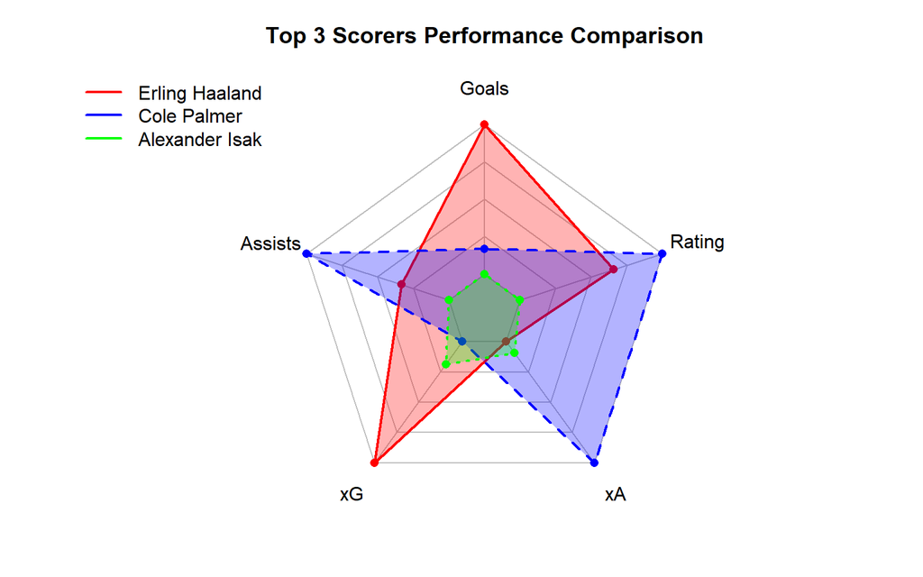

```r
# Example for comparing top 3 scorers
radar_plot_top_scorers <- data_player %>%
  arrange(desc(Top_scorer)) %>%
  head(3) %>%
  select(
    ParticipantName,
    Goals = Top_scorer,
    Assists,
    `xG` = `Expected_goals_(xG)`,
    `xA` = `Expected_assist_(xA)`,
    Rating = FotMob_rating
  ) %>%
  # Prepare data for radar plot
  column_to_rownames("ParticipantName") %>%
  # Add max and min rows required by fmsb
  rbind(
    apply(., 2, max),  # Max values
    apply(., 2, min),  # Min values
    .
  )

# Create the radar plot
par(mar = c(1, 3, 3, 1))  # Adjust margins
radarchart(
  radar_plot_top_scorers,
  pcol = c("red", "blue", "green"),  # Line colors
  pfcol = scales::alpha(c("red", "blue", "green"), 0.3),  # Fill colors
  plwd = 2,  # Line width
  cglcol = "grey",  # Grid color
  cglty = 1,  # Grid line type
  axislabcol = "grey50",  # Axis label color
  caxislabels = seq(0, 1, 0.25),  # Custom axis labels
  title = "Top 3 Scorers Performance Comparison"
)
# Add legend
legend(
  "topleft",
  legend = rownames(radar_plot_top_scorers)[-(1:2)],
  col = c("red", "blue", "green"),
  lwd = 2,
  bty = "n"
)
```

**Insights**:

- The comparison highlights the strengths and weaknesses of the top 3 players across key metrics.
- This visualization is particularly useful for fantasy football managers looking to evaluate player performance holistically.

# 4 Conclusion

These findings highlight the potential of web scraping and data analysis in sports analytics. Future work could involve expanding the dataset to include more seasons or exploring advanced statistical models for player evaluation.

# 5 References

1. [FutMob URL](https://www.fotmob.com/en-GB/leagues/47/stats/premier-league?season=2023-2024): Source of football statistics.
2. [De Bruyne’s new contract agreed after data analysts convinced him Man City were able to match his ambitions – and vice versa](https://www.nytimes.com/athletic/2503139/2021/04/07/de-bruynes-new-contract-agreed-after-data-analysts-convinced-him-man-city-were-able-to-match-his-ambitions-and-vice-versa/) : Article about how data changes football contract negotiations.
3. [Fut GG url](https://www.fut.gg/players/) : described in notes, used for page scraping.
4. [GitHub link of this project](https://github.com/M3LNYK/FantasyFootball) : this project is available on my GitHub, I will push it later.

## 5.1 Notes:

During one of the classes you told me that, this approach, described above, is not recommended to do and will not be enough or sufficient to pass the project. Unfortunately, I could not scrap the data other than through JSON file from the selected web page, therefore I decided create another, additional file where I showcase a bit that I know how to scrap frontend data, but it is not related to the project or overall business idea. This scrapper will be in `fut_demo.R` file and can scrap FIFA cards stats from the web page. At first, it scans given page for links to players’ cards as well as amount of pages to scrap and after scraps individually each card link for cards data and details. If you’ll have any further questions, please contact me via email - 251528@student.pwr.edu.pl